# Use Actual Stock Assessment

This vignette demonstrates how to use an **actual stock assessment model** output to develop an operating model (OM) for `SPASAM.MSE`, while keeping the historical population dynamics fixed to the fitted stock trajectory.

In many MSE examples, process random effects (for example, recruitment deviations) are simulated for the entire time series. That means the historical population trajectory can vary from one random seed to another. However, when an OM is built from a real stock assessment, users may prefer the historical period to reflect the fitted trajectory of the real stock as closely as possible. This can make the evaluation of management procedures more meaningful for management applications.

The key idea in this vignette is:

1. **Fit a stock assessment model to real data**
   - Here we use Georges Bank yellowtail flounder data.
2. **Extract estimated parameters and historical process deviations**
   - These are used to construct an OM for MSE.
3. **Fix the historical period**
   - The historical trajectory is held constant across seeds, so the underlying population dynamics in the historical period do not change.
4. **Simulate only the feedback period**
   - Random deviations are still drawn during the feedback years, so future trajectories can differ across seeds.

This vignette provides a full end-to-end example:

- fit the historical stock assessment,
- build the projection OM,
- fix the historical period,
- simulate the future,
- run MSE.

This is an illustrative example using **Georges Bank yellowtail flounder**.

### 1. Load `WHAM` and `SPASAM.MSE`

```r
# Install if needed.
# This fixed-history workflow is currently available in the lab branch.
# remotes::install_github("lichengxue/SPASAM.MSE@lab", upgrade = "never")

library(wham)
library(SPASAM.MSE)
library(dplyr)
library(ggplot2)
```

### 2. Read stock assessment data and define global settings

We use Georges Bank yellowtail flounder ASAP input data and set up a short MSE feedback period.

```r
gb_file <- system.file("extdata", "GBK.DAT", package = "SPASAM.MSE")
gb_dat <- read_asap3_dat(gb_file)

input_hist <- prepare_wham_input(gb_dat)
input      <- prepare_wham_input(gb_dat)

n_stocks  <- 1L
n_regions <- 1L
n_ages    <- 6L
n_indices <- 3L
n_fleets  <- 1L
n_seasons <- 1L

year_start <- 1973L
year_end   <- 2022L
MSE_years  <- 10L

n_hist_years <- year_end - year_start + 1L
n_proj_years <- n_hist_years + MSE_years

base_years      <- year_start:year_end
assess_interval <- 2L

stopifnot(MSE_years %% assess_interval == 0L)

assess_years <- seq(
  tail(base_years, 1),
  year_end + MSE_years - assess_interval,
  by = assess_interval
)

# Historical period is fixed.
# Only years from first_free_year onward are allowed to vary.
first_free_year <- 51L
```

### 3. Fit the historical stock assessment model

#### 3.1 Biological inputs for the historical period

```r
user_maturity_hist <- array(NA_real_, dim = c(n_stocks, n_hist_years, n_ages))
user_maturity_hist[, 1:n_hist_years, ] <- input$data$mature

user_waa_hist <- list()
user_waa_hist$waa <- array(NA_real_, dim = c(5, n_hist_years, n_ages))
user_waa_hist$waa[, 1:n_hist_years, ] <- input$data$waa
user_waa_hist$waa_pointer_fleets   <- input$data$waa_pointer_fleets
user_waa_hist$waa_pointer_indices  <- input$data$waa_pointer_indices
user_waa_hist$waa_pointer_totcatch <- input$data$waa_pointer_ssb
user_waa_hist$waa_pointer_ssb      <- input$data$waa_pointer_ssb
user_waa_hist$waa_pointer_M        <- input$data$waa_pointer_M

fracyr_spawn <- gb_dat[[1]]$dat$fracyr_spawn
```

#### 3.2 Observation settings for catch and indices

```r
catch_info_hist <- list(
  catch_cv      = 0.05,
  catch_Neff    = 50,
  use_agg_catch = 1,
  use_catch_paa = 1
)

index_info_hist <- list(
  index_cv        = rep(0.5, n_indices),
  index_Neff      = rep(25, n_indices),
  fracyr_indices  = c(0.25, 0.75, 0.25),
  q               = rep(0.2, n_indices),
  use_indices     = rep(1, n_indices),
  use_index_paa   = rep(1, n_indices),
  units_indices   = rep(2, n_indices),
  units_index_paa = rep(2, n_indices)
)
```

#### 3.3 Build the historical model scaffold

```r
info_hist <- SPASAM.MSE::generate_basic_info(
  n_stocks = n_stocks,
  n_regions = n_regions,
  n_indices = n_indices,
  n_fleets = n_fleets,
  n_seasons = n_seasons,
  base.years = year_start:year_end,
  n_feedback_years = 0L,
  n_ages = n_ages,
  catch_info = catch_info_hist,
  index_info = index_info_hist,
  user_waa = user_waa_hist,
  user_maturity = user_maturity_hist,
  fracyr_spawn = fracyr_spawn
)

basic_info_hist     <- info_hist$basic_info
catch_info_use_hist <- info_hist$catch_info
index_info_use_hist <- info_hist$index_info
F_info_hist         <- info_hist$F

catch_info_use_hist$agg_catch[1:n_hist_years, ]     <- input$data$agg_catch
catch_info_use_hist$catch_paa[, 1:n_hist_years, ]   <- input$data$catch_paa
index_info_use_hist$agg_indices[1:n_hist_years, ]   <- input$data$agg_indices
index_info_use_hist$index_paa[, 1:n_hist_years, ]   <- input$data$index_paa
index_info_use_hist$use_indices[1:n_hist_years, ]   <- input$data$use_indices
index_info_use_hist$use_index_paa[1:n_hist_years, ] <- input$data$use_index_paa
```

#### 3.4 Selectivity, natural mortality, and recruitment process

```r
sel_hist <- list(
  model = c("age-specific", "logistic", "logistic", "logistic"),
  re    = c("ar1_y", "none", "none", "none"),
  initial_pars = list(
    c(0.1, 0.25, 0.5, 1, 1, 1),
    c(2, 0.3),
    c(2, 0.3),
    c(2, 0.3)
  ),
  fix_pars = list(c(4:6), NULL, NULL, NULL)
)

M_hist <- list(
  model = "constant",
  initial_means = array(
    c(0.57, 0.33, 0.26, 0.23, 0.22, 0.22),
    dim = c(n_stocks, n_regions, n_ages)
  )
)

sigma_vals_hist <- array(0, dim = c(n_stocks, n_regions, n_ages))
sigma_vals_hist[, , 1] <- 0.5

NAA_re_hist <- list(
  N1_model      = rep("equilibrium", n_stocks),
  sigma         = rep("rec", n_stocks),
  cor           = rep("iid", n_stocks),
  recruit_model = 3,
  sigma_vals    = sigma_vals_hist
)
```

#### 3.5 Prepare and fit the historical model

```r
input_histfit <- prepare_wham_input(
  basic_info  = basic_info_hist,
  selectivity = sel_hist,
  M           = M_hist,
  NAA_re      = NAA_re_hist,
  catch_info  = catch_info_use_hist,
  index_info  = index_info_use_hist,
  F           = F_info_hist,
  age_comp    = "logistic-normal-pool0"
)

input_histfit <- update_waa(input_histfit, waa_info = info_hist$par_inputs$user_waa)

input_e <- prepare_wham_input(gb_dat)
input_histfit$data$agg_index_sigma[1:n_hist_years, ] <- input_e$data$agg_index_sigma
input_histfit$data$use_indices[1:n_hist_years, ]     <- input_e$data$use_indices
input_histfit$data$use_index_paa[1:n_hist_years, ]   <- input_e$data$use_index_paa
```

```r
generate_remove_years <- function(mat) {
  lz <- lapply(seq_len(ncol(mat)), function(j) which(mat[, j] == 0))
  if (all(lengths(lz) == 0)) return(NULL)
  max_rows <- max(sapply(lz, length))
  out <- matrix(NA_integer_, nrow = max_rows, ncol = length(lz))
  for (j in seq_along(lz)) {
    if (length(lz[[j]])) out[seq_along(lz[[j]]), j] <- lz[[j]]
  }
  out
}

remove_agg_years1 <- generate_remove_years(input_e$data$use_indices)
remove_paa_years1 <- generate_remove_years(input_e$data$use_index_paa)

input_histfit <- update_input_index_info(
  input_histfit,
  agg_index_sigma = input_histfit$data$agg_index_sigma,
  index_Neff      = input_histfit$data$index_Neff,
  remove_agg = TRUE,
  remove_agg_pointer = 1:3,
  remove_agg_years = remove_agg_years1,
  remove_paa = TRUE,
  remove_paa_pointer = 1:3,
  remove_paa_years = remove_paa_years1
)
```

```r
om_file <- system.file("extdata", "OM.RDS", package = "SPASAM.MSE")

if (file.exists(om_file)) {

  OM <- readRDS(om_file)

} else {

  OM <- fit_wham(
    input_histfit,
    do.fit = TRUE,
    do.brps = TRUE,
    do.retro = FALSE,
    do.osa = FALSE,
    MakeADFun.silent = TRUE
  )

  saveRDS(OM, file.path(tempdir(), "OM.RDS"))

}

check_convergence(OM)
```

### 4. Build the projection operating model

Next, we extend the model from the historical period into the feedback period. The historical years will later be fixed to the fitted stock trajectory, while the feedback years will be allowed to vary by seed.

#### 4.1 Biological inputs over the full modeled period

```r
user_maturity <- array(NA_real_, dim = c(n_stocks, n_proj_years, n_ages))
user_maturity[, 1:n_hist_years, ] <- OM$input$data$mature[, 1:n_hist_years, ]
for (iy in (n_hist_years + 1L):n_proj_years) {
  user_maturity[, iy, ] <- OM$input$data$mature[, n_hist_years, , drop = FALSE]
}

user_waa <- list()
user_waa$waa <- array(NA_real_, dim = c(5, n_proj_years, n_ages))
user_waa$waa[, 1:n_hist_years, ] <- OM$input$data$waa[, 1:n_hist_years, ]
for (iy in (n_hist_years + 1L):n_proj_years) {
  user_waa$waa[, iy, ] <- OM$input$data$waa[, n_hist_years, , drop = FALSE]
}

user_waa$waa_pointer_fleets   <- OM$input$data$waa_pointer_fleets
user_waa$waa_pointer_indices  <- OM$input$data$waa_pointer_indices
user_waa$waa_pointer_totcatch <- OM$input$data$waa_pointer_totcatch
user_waa$waa_pointer_ssb      <- OM$input$data$waa_pointer_ssb
user_waa$waa_pointer_M        <- OM$input$data$waa_pointer_M
```

#### 4.2 Catch and index settings for the OM

```r
catch_info <- list(
  catch_cv      = 0.05,
  catch_Neff    = 50,
  use_agg_catch = 1,
  use_catch_paa = 1
)

index_info <- list(
  index_cv        = rep(0.5, n_indices),
  index_Neff      = rep(25, n_indices),
  fracyr_indices  = c(0.25, 0.75, 0.25),
  q               = c(2.110e-4, 2.247e-4, 2.683e-4),
  use_indices     = rep(1, n_indices),
  use_index_paa   = rep(1, n_indices),
  units_indices   = rep(2, n_indices),
  units_index_paa = rep(2, n_indices)
)
```

#### 4.3 Build the projection scaffold

```r
info <- SPASAM.MSE::generate_basic_info(
  n_stocks = n_stocks,
  n_regions = n_regions,
  n_indices = n_indices,
  n_fleets = n_fleets,
  n_seasons = n_seasons,
  base.years = year_start:year_end,
  n_feedback_years = MSE_years,
  n_ages = n_ages,
  catch_info = catch_info,
  index_info = index_info,
  user_waa = user_waa,
  user_maturity = user_maturity,
  fracyr_spawn = fracyr_spawn
)

basic_info     <- info$basic_info
catch_info_use <- info$catch_info
index_info_use <- info$index_info
```

#### 4.4 Initialize fishing mortality

```r
F_info <- info$F
F_info$F[1:n_hist_years, ] <- OM$rep$Fbar[1:n_hist_years, 1, drop = FALSE]
```

#### 4.5 Define selectivity, M, and process settings for the OM

```r
sel3 <- list(
  model = c("age-specific", "logistic", "logistic", "logistic"),
  re    = c("ar1_y", "none", "none", "none"),
  initial_pars = list(
    c(0.05, 0.3, 0.7, 0.875, 0.9, 1),
    c(2.305, 0.327),
    c(1.611, 0.483),
    c(2.135, 0.217)
  ),
  fix_pars = list(c(4:6), NULL, NULL, NULL)
)

M <- list(
  model = "constant",
  initial_means = array(
    c(0.57, 0.33, 0.26, 0.23, 0.22, 0.22),
    dim = c(n_stocks, n_regions, n_ages)
  )
)

sigma_vals <- array(0, dim = c(n_stocks, n_regions, n_ages))
sigma_vals[, , 1] <- exp(OM$parList$log_NAA_sigma[, , 1])
sigma_vals[, , 2:n_ages] <- exp(OM$parList$log_NAA_sigma[, , 2:n_ages])

recruit_pars_use <- exp(as.numeric(OM$parList$mean_rec_pars[1, ]))

NAA_re <- list(
  N1_model      = rep("age-specific-fe", n_stocks),
  sigma         = rep("rec+1", n_stocks),
  cor           = rep("iid", n_stocks),
  recruit_model = 3,
  recruit_pars  = list(recruit_pars_use),
  sigma_vals    = sigma_vals
)
```

#### 4.6 Build the unfitted projection OM input

```r
om_input_P <- wham::prepare_wham_input(
  basic_info  = basic_info,
  selectivity = sel3,
  M           = M,
  NAA_re      = NAA_re,
  catch_info  = catch_info_use,
  index_info  = index_info_use,
  F           = F_info,
  age_comp    = "logistic-normal-pool0"
)

waa_info <- info$par_inputs$user_waa
om_input_P <- SPASAM.MSE::update_waa(om_input_P, waa_info = waa_info)

om_input_P$par$catch_paa_pars <- OM$parList$catch_paa_pars
om_input_P$par$index_paa_pars <- OM$parList$index_paa_pars
om_input_P$par$sel_repars     <- OM$parList$sel_repars

for (i in 1:n_regions) {
  om_input_P$par$log_N1[i, i, ] <- log(OM$rep$N1)[i, i, ]
}

om_input_P$data$agg_index_sigma[1:n_hist_years, ] <- input_hist$data$agg_index_sigma
om_input_P$data$use_indices[1:n_hist_years, ]     <- input_hist$data$use_indices
om_input_P$data$use_index_paa[1:n_hist_years, ]   <- input_hist$data$use_index_paa

for (iy in (n_hist_years + 1L):n_proj_years) {
  om_input_P$data$agg_index_sigma[iy, ] <- input_hist$data$agg_index_sigma[n_hist_years, ]
}
```

```r
loc_zeros_agg <- lapply(seq_len(ncol(input_hist$data$use_indices)), function(j) {
  which(input_hist$data$use_indices[, j] == 0)
})

loc_zeros_paa <- lapply(seq_len(ncol(input_hist$data$use_index_paa)), function(j) {
  which(input_hist$data$use_index_paa[, j] == 0)
})

max_agg <- max(sapply(loc_zeros_agg, length))
max_paa <- max(sapply(loc_zeros_paa, length))

remove_agg_years1 <- if (max_agg > 0) {
  out <- matrix(NA_integer_, nrow = max_agg, ncol = length(loc_zeros_agg))
  for (j in seq_along(loc_zeros_agg)) {
    if (length(loc_zeros_agg[[j]])) {
      out[seq_along(loc_zeros_agg[[j]]), j] <- loc_zeros_agg[[j]]
    }
  }
  out
} else NULL

remove_paa_years1 <- if (max_paa > 0) {
  out <- matrix(NA_integer_, nrow = max_paa, ncol = length(loc_zeros_paa))
  for (j in seq_along(loc_zeros_paa)) {
    if (length(loc_zeros_paa[[j]])) {
      out[seq_along(loc_zeros_paa[[j]]), j] <- loc_zeros_paa[[j]]
    }
  }
  out
} else NULL

om_input_P <- SPASAM.MSE::update_input_index_info(
  om_input_P,
  agg_index_sigma = om_input_P$data$agg_index_sigma,
  index_Neff      = om_input_P$data$index_Neff,
  remove_agg = TRUE,
  remove_agg_pointer = 1:3,
  remove_agg_years = remove_agg_years1,
  remove_paa = TRUE,
  remove_paa_pointer = 1:3,
  remove_paa_years = remove_paa_years1
)
```

### 5. Compile the unfitted projection OM

```r
om_input_P$data$do_simulate_N_re <- 1L

unfitted_om_P <- fit_wham(
  om_input_P,
  do.fit = FALSE,
  do.brps = FALSE,
  MakeADFun.silent = TRUE
)
```

### 6. Fix the historical period and free only the feedback period

This is the key step. We overwrite the historical `log_NAA` values using the fitted historical model so that the historical population trajectory remains fixed across seeds. Only the future block is left free and can be simulated.

```r
unfitted_om_P$input$random <- "log_NAA"
unfitted_om_P$input$data$do_simulate_N_re <- 1L

unfitted_om_P$input$par$log_N1 <- log(OM$rep$N1)
if (!is.null(unfitted_om_P$parList$log_N1)) {
  unfitted_om_P$parList$log_N1 <- log(OM$rep$N1)
}

hist_idx <- 1:(first_free_year - 2L)
unfitted_om_P$input$par$log_NAA[1, 1, hist_idx, ] <-
  log(OM$rep$NAA[1, 1, hist_idx + 1L, ])

if (!is.null(unfitted_om_P$parList$log_NAA)) {
  unfitted_om_P$parList$log_NAA[1, 1, hist_idx, ] <-
    log(OM$rep$NAA[1, 1, hist_idx + 1L, ])
}
```

```r
logNAA_dim <- dim(unfitted_om_P$input$par$log_NAA)
future_idx_start <- first_free_year - 1L
future_idx <- future_idx_start:logNAA_dim[3]

m <- array(NA_integer_, dim = logNAA_dim)
m[1, 1, future_idx, ] <- 1L
m[!is.na(m)] <- seq_len(sum(!is.na(m)))

unfitted_om_P$input$map$log_NAA <- factor(m)
if (!is.null(unfitted_om_P$env$map)) {
  unfitted_om_P$env$map$log_NAA <- unfitted_om_P$input$map$log_NAA
}
```

```r
last_fixed_idx <- first_free_year - 2L
if (last_fixed_idx >= 1L) {
  unfitted_om_P$input$par$log_NAA[1, 1, future_idx, ] <-
    array(
      unfitted_om_P$input$par$log_NAA[1, 1, last_fixed_idx, ],
      dim = c(1, 1, length(future_idx), logNAA_dim[4])
    )

  if (!is.null(unfitted_om_P$parList$log_NAA)) {
    unfitted_om_P$parList$log_NAA[1, 1, future_idx, ] <-
      array(
        unfitted_om_P$parList$log_NAA[1, 1, last_fixed_idx, ],
        dim = c(1, 1, length(future_idx), logNAA_dim[4])
      )
  }
}

unfitted_om_P$parList$logit_selpars <- OM$parList$logit_selpars
unfitted_om_P$parList$selpars_re    <- OM$parList$selpars_re
```

```r
unfitted_om_P <- fit_wham(
  unfitted_om_P$input,
  do.fit = FALSE,
  do.brps = FALSE,
  MakeADFun.silent = TRUE
)
```

### 7. Simulate only the future block

Now we simulate the OM while keeping the historical period fixed. The future trajectory depends on the seed, but the historical trajectory remains unchanged.

```r
seed <- 12345L

om_future <- update_om_fn(
  unfitted_om_P,
  seed = seed,
  random = "log_NAA",
  process_fix = TRUE,
  first_free_year = first_free_year
)
```

### 8. Diagnostics

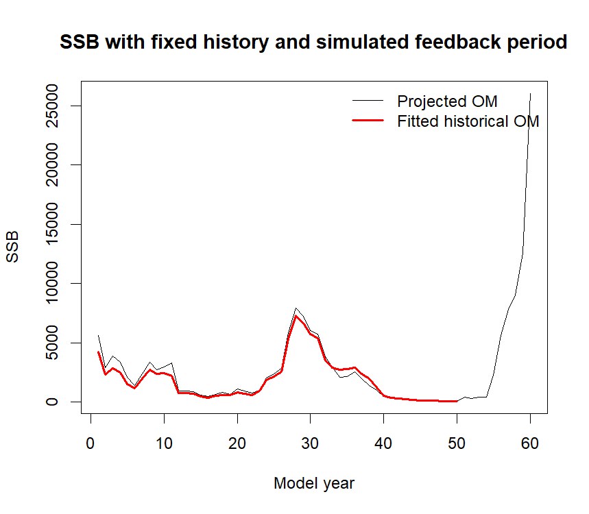

Figure 1

```r
plot(
  om_future$rep$SSB,
  type = "l",
  main = "SSB with fixed history and simulated feedback period",
  xlab = "Model year",
  ylab = "SSB"
)
lines(1:n_hist_years, OM$rep$SSB[1:n_hist_years], col = "red", lwd = 2)

legend(
  "topright",
  legend = c("Projected OM", "Fitted historical OM"),
  col = c("black", "red"),
  lwd = c(1, 2),
  bty = "n"
)
```

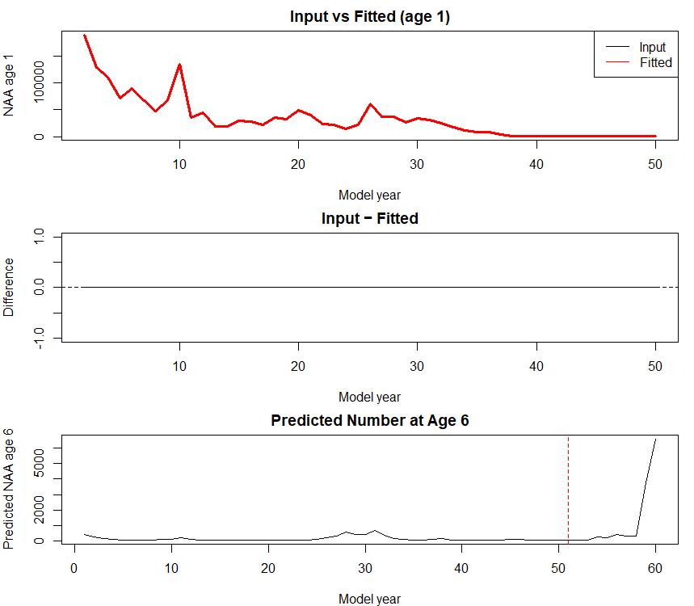

Figure 2

```r
s <- 1
r <- 1
hist_idx <- 1:(n_hist_years - 1L)

layout(matrix(c(1,2,3), nrow = 3, byrow = TRUE))
par(mar = c(4,4,2,1))

# Extract series
input_series <- exp(om_future$input$par$log_NAA[s, r, hist_idx, 1])
fitted_series <- OM$rep$NAA[s, r, hist_idx + 1L, 1]

# Panel 1 — overlay
plot(hist_idx + 1, input_series,
     type = "l",
     lwd = 2,
     xlab = "Model year",
     ylab = "NAA age 1",
     main = "Input vs Fitted (age 1)")
lines(hist_idx + 1, fitted_series, col = "red", lwd = 2)
legend("topright", c("Input", "Fitted"), col=c("black","red"), lty=1)

# Panel 2 — difference
plot(hist_idx + 1,
     input_series - fitted_series,
     type = "l",
     xlab = "Model year",
     ylab = "Difference",
     main = "Input − Fitted")
abline(h = 0, lty = 2)

# Panel 3 — predicted NAA age 6
plot(
  om_future$rep$pred_NAA[s, r, , 6],
  type = "l",
  main = "Predicted Number at Age 6",
  xlab = "Model year",
  ylab = "Predicted NAA age 6"
)
abline(v = first_free_year, lty = 2, col = "red")
```

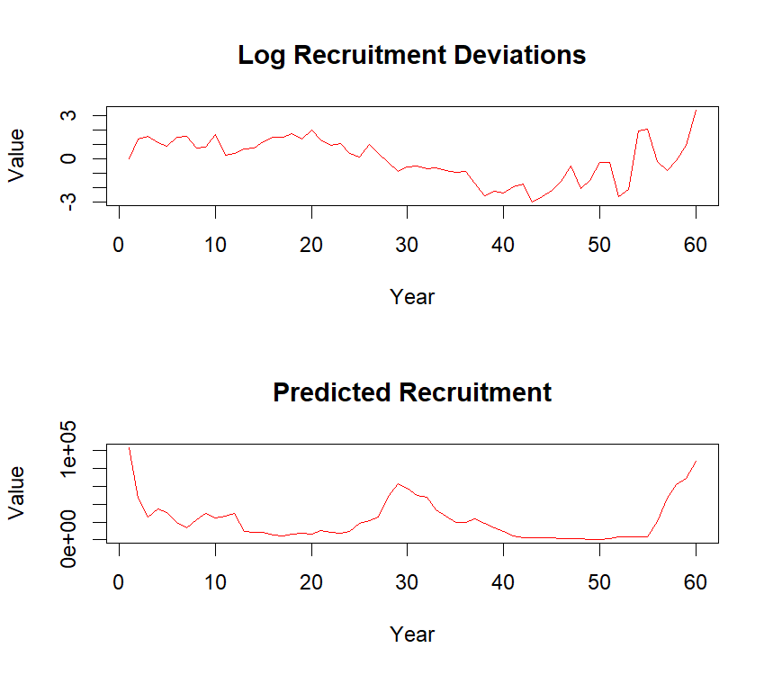

Figure 3

```r
par(mfrow = c(2, 1))

# Recruitment deviations
matplot(
  om_future$rep$NAA_devs[, , , 1],
  type = "l",
  lty = 1,
  col = rainbow(dim(om_future$rep$NAA_devs)[1]),
  main = "Log Recruitment Deviations",
  xlab = "Year",
  ylab = "Value"
)

# Predicted recruitment
matplot(
  om_future$rep$pred_NAA[, , , 1],
  type = "l",
  lty = 1,
  col = rainbow(dim(om_future$rep$pred_NAA)[1]),
  main = "Predicted Recruitment",
  xlab = "Year",
  ylab = "Value"
)

par(mfrow = c(1,1))
```

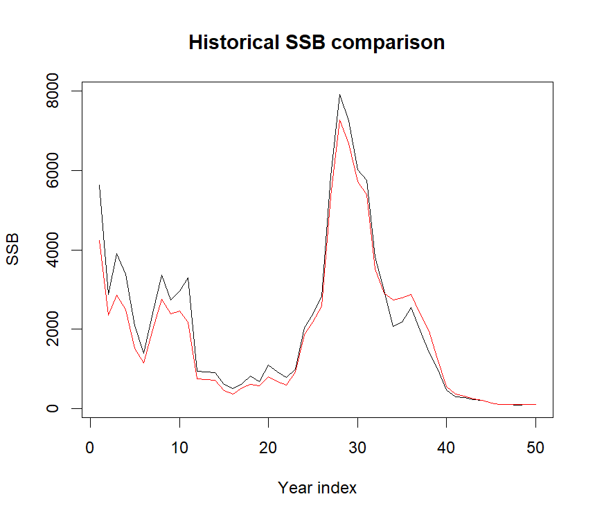

Figure 4

```r
hist_diff <- om_future$rep$NAA[, , 1:n_hist_years, ] -
  OM$rep$NAA[, , 1:n_hist_years, ]
print(hist_diff)

plot(
  om_future$rep$SSB[1:n_hist_years],
  type = "l",
  main = "Historical SSB comparison",
  xlab = "Year index",
  ylab = "SSB"
)
lines(OM$rep$SSB[1:n_hist_years], col = "red")
```

### 9. Run MSE

We now run MSE using the projected OM with fixed historical dynamics. In this example, we compare two harvest control rule settings: 75% FXSPR and 100% FXSPR.

#### 9.1 Define assessment years and EM settings

```r
assess_interval <- 2L
base_years      <- year_start:year_end
terminal_year   <- tail(base_years, 1)

assess_years <- seq(
  terminal_year,
  year_end + MSE_years - assess_interval,
  by = assess_interval
)

NAA_re_em <- NAA_re
NAA_re_em$N1_model <- "equilibrium"
NAA_re_em$sigma    <- "rec"
NAA_re_em$cor      <- "iid"

update_catch_info_list <- list(
  agg_catch_sigma = om_input_P$data$agg_catch_sigma,
  catch_Neff      = om_input_P$data$catch_Neff
)

update_index_info_list <- list(
  agg_index_sigma = om_input_P$data$agg_index_sigma,
  index_Neff      = om_input_P$data$index_Neff,
  remove_agg = TRUE,
  remove_agg_pointer = 1:3,
  remove_agg_years = remove_agg_years1,
  remove_paa = TRUE,
  remove_paa_pointer = 1:3,
  remove_paa_years = remove_paa_years1
)
```

#### 9.2 MSE run with 75% FXSPR

```r
hcr1 <- list(
  hcr.type = 1,
  hcr.opts = list(use_FXSPR = TRUE, percentFXSPR = 75)
)

mod1_file <- system.file("extdata", "mod1.RDS", package = "SPASAM.MSE")

if (file.exists(mod1_file)) {

  mod1 <- readRDS(mod1_file)

} else {

  mod1 <- loop_through_fn(
    om = om_future,
    em_info = info,
    random = "log_NAA",
    M_em = M,
    sel_em = sel3,
    NAA_re_em = NAA_re_em,
    age_comp_em = "logistic-normal-pool0",
    em.opt = list(
      separate.em = FALSE,
      separate.em.type = 1,
      do.move = FALSE,
      est.move = FALSE
    ),
    update_index_info = update_index_info_list,
    update_catch_info = update_catch_info_list,
    assess_years = assess_years,
    assess_interval = assess_interval,
    base_years = base_years,
    year.use = 50,
    add.years = TRUE,
    seed = 12345L,
    hcr = hcr1,
    save.sdrep = FALSE,
    save.last.em = TRUE,
    FXSPR_init = 0.5,
    process_fix = TRUE,
    first_free_year = 51
  )

}
```

#### 9.3 MSE run with 100% FXSPR

```r
hcr2 <- list(
  hcr.type = 1,
  hcr.opts = list(use_FXSPR = TRUE, percentFXSPR = 100)
)

mod2_file <- system.file("extdata", "mod2.RDS", package = "SPASAM.MSE")

if (file.exists(mod2_file)) {

  mod2 <- readRDS(mod2_file)

} else {

  mod2 <- loop_through_fn(
    om = om_future,
    em_info = info,
    random = "log_NAA",
    M_em = M,
    sel_em = sel3,
    NAA_re_em = NAA_re_em,
    age_comp_em = "logistic-normal-pool0",
    em.opt = list(
      separate.em = FALSE,
      separate.em.type = 1,
      do.move = FALSE,
      est.move = FALSE
    ),
    update_index_info = update_index_info_list,
    update_catch_info = update_catch_info_list,
    assess_years = assess_years,
    assess_interval = assess_interval,
    base_years = base_years,
    year.use = 50,
    add.years = TRUE,
    seed = 12345L,
    hcr = hcr2,
    save.sdrep = FALSE,
    save.last.em = TRUE,
    FXSPR_init = 0.5,
    process_fix = TRUE,
    first_free_year = 51
  )

}
```

### 10. Plot MSE results

Below we compare the realized OM trajectories under the two HCR settings.

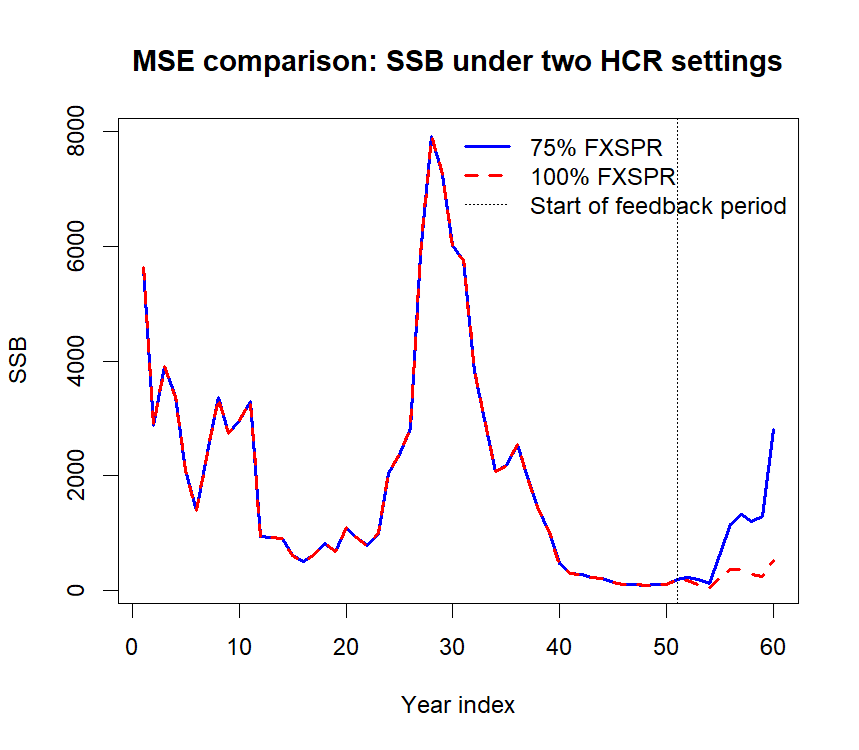

Figure 5

```r
plot(
  mod1$om$rep$SSB,
  type = "l",
  lwd = 2,
  col = "blue",
  xlab = "Year index",
  ylab = "SSB",
  main = "MSE comparison: SSB under two HCR settings"
)

lines(
  mod2$om$rep$SSB,
  col = "red",
  lwd = 2,
  lty = 2
)

abline(v = first_free_year, lty = 3)

legend(
  "topright",
  legend = c("75% FXSPR", "100% FXSPR", "Start of feedback period"),
  col = c("blue", "red", "black"),
  lty = c(1, 2, 3),
  lwd = c(2, 2, 1),
  bty = "n"
)
```

### 11. Summary

This vignette showed how to build an MSE operating model directly from a fitted stock assessment model while keeping the historical population trajectory fixed.

The main advantage of this workflow is that the historical period remains anchored to the fitted trajectory of the real stock, rather than changing across seeds because of newly simulated historical process deviations. This can be especially useful when the goal is to evaluate management procedures under a historical stock trajectory that is already scientifically accepted or management-relevant.

In this example:

- the historical stock assessment was fit to real Georges Bank yellowtail flounder data,
- estimated parameters and historical trajectory were used to construct the OM,
- the historical period was fixed,
- only the feedback period was simulated,
- MSE was run under two HCR settings.

At present, users should apply this workflow only to OMs where **recruitment is the only random process tested in the historical fixing workflow**.